# Replacement Class - Introduction to spatial data

Lucas Adams

2023-11-13

This notebook supports an asynchronous lecture meant to introduce you to some basics of spatial data. The lecture will be provided via Echo360.

I will provide you with a partially completed notebook to assist your work.

This notebooks will focus on “spatial data” and also accessing demographic data in R.

Key topics for today:

- Using `here` package
- Using the `/data_raw/` directory
- Reminder on joins (focus: left join)
- Our Spatial Data
  - Neighborhoods
  - Joining with non-spatial data
  - Census data
  - Joining with spatial data
- ignore html in git

## Packages

Standards:

```r
library(knitr)
library(tidyverse)
library(janitor)
library(lubridate) # because we will probably see some dates
library(here) # more easily access files in your project
```

Some additional packages focuses on today’s work:

```r
library(sf) # working with simple features - geospatial
library(tmap)
library(tidycensus)
```

A link to a book on `tmap`: https://r-tmap.github.io/

## Using the Neighborhood Geospatial Data (using /data)

I will use the GeoJSON file. (Newer, not necessarily better, but … a single file. Not smaller, but … this one is not big.)

https://opendata.dc.gov/datasets/DCGIS::dc-health-planning-neighborhoods/about

## Using the Neighborhood Geospatial Data (using /data)

Load the neighborhood geospatial data as `neigh`.

```r
neigh = st_read(here("data_raw", "DC_Health_Planning_Neighborhoods.geojson")) %>% clean_names()
```

Ensure it plots.

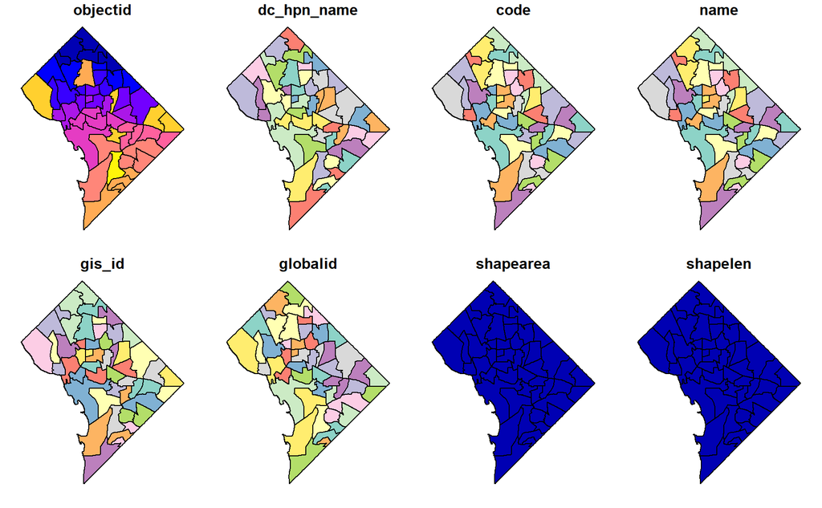

```r
plot(neigh)
```

## Investigating joining spatial and non-spatial data

Download the DC covid datase for positive cases and store at an appropriate place in your project.

Read the data as `df_c` and be sure to clean names.

```r
df_c = read_csv(here("data_raw", "DC_COVID-19_Total_Positive_Cases_by_Neighborhood.csv")) %>% clean_names()
```

Now - let’s focus on a particular date (for no reason other than simplifying our analysis).

```r
df_cases = df_c %>%
  filter(as_date(date_reported) == "2021-11-17") %>%
  separate(neighborhood, into=c("code", "name"), sep = ":")
```

Create the dataframe `df_cases`:

```r
df_cases=df_c %>%
  filter(as_date(date_reported) == "2021-11-17") %>%
  separate(neighborhood,into=c("code","name"),sep = ":") %>%
  mutate(code=case_when(code=="N35" ~"N0",
                        TRUE ~ code)) %>%
  select(-date_reported)
```

## Regular joining (of dataframes)

Join the dataframes and make a chloropleth map using tmap.

```r
neigh2 = left_join(neigh, df_cases, by = c("code"))
```

## Joining with other spatial data

Let’s get some data using `tidycensus`. Need an API key https://api.census.gov/data/key_signup.html

```r
census_api_key("YOUR KEY HERE")
```

What data is available — and what is the variable name?

(We are interested in the 5year American Community Survey.)

Get some data:

```r
df_cencus=get_acs(geography = "tract",
                  variables=c("median_inc"="B06011_001",
                              "pop"="B01001_001",
                              "pop_black"="B02009_001"),
                  state="DC",geometry=TRUE,year=2021)
```

Make a plot to verify that you read the data:

### A BETTER VISUALIZATION

It’s in long format. Let’s make it wide.

```r
df_cens=df_cencus %>%
  select(-moe) %>%
  pivot_wider(names_from = "variable",
              values_from = "estimate")



tm_shape(df_cens) +tm_polygons("median_inc",alpha=.5)
```

### How to join

Consider this problem:

```r
  tm_shape(neigh2) +tm_borders(col="blue",lwd=5,alpha=.2)+
  tm_shape(df_cens) +tm_borders(col="red",lwd=1,alpha=.3)
```

OK - follow the challenging code elements:

```r
df_j=st_join(df_cens,neigh2)
```

You need to add a coordinate system to the census data:

But which way do we join — and — think about how it should “aggregate” the data.

Since we want the geometry for the NEIGHBORHOODS, we need a different work a little harder:

```r
df1=df_j %>% select(median_inc,pop,pop_black,code) %>%
  group_by(code) %>%
  summarise(pop_n=sum(pop),
            pop_black_n=sum(pop_black),
            adj_median_income=sum(pop*median_inc)/pop_n)

plot(df1)
```

Now that we are aggregating in the right way, we can join.

```r
df2=left_join(neigh2,df1)

df2=left_join(neigh2,df1 %>% st_set_geometry(NULL))
```

And visualize:

```r
df2=df2 %>% mutate(black_perc=pop_black_n/pop_n, covid_rate=total_positives/pop_n)
tm_shape(df2)+tm_polygons(c("adj_median_income","covid_rate","black_perc"))
```

Improve that visualization: